# Getting started with quardplot

quardplot makes aligned locus figures and tables from GWAS results, a gene annotation (GFF3 or GTF) and genotypes (VCF or HapMap). This vignette runs the main steps on a small simulated rice data set. For a longer, step-by-step guide with your own files, run `quard_guide()`: it copies the guide `quard_plot_examples.R` into your folder.

## 1. Choose the species

The species gives the chromosome lengths of the reference genome for the genome-wide plots.

```r
library(quardplot)
list_species()[, c("species", "reference_genome", "chromosomes")]
```

```
#>        species          reference_genome chromosomes
#> 1         rice          IRGSP-1.0 / MSU7          12
#> 2  arabidopsis                    TAIR10           5
#> 3       tomato SL4.0 (ITAG4.0 / ITAG4.1)          12
#> 4        human             GRCh38 / hg38          24
#> 5 human_grch37             GRCh37 / hg19          24
#> 6        mouse             GRCm39 / mm39          21
#> 7 mouse_grcm38             GRCm38 / mm10          21
```

```r
set_species("rice")
```

```
#> Species: Rice (Oryza sativa, Nipponbare) - reference genome IRGSP-1.0 / MSU7 (12 chromosomes, 373.2 Mb; lengths: built-in).
#> All plots now use these chromosome lengths. Your GWAS, genotype (VCF/HapMap) and GFF files must use the same reference genome.
```

For a species that is not built in, give its chromosome lengths, for example `set_species("pepper", chrom_sizes = "pepper_genome.fa.fai")`.

## 2. Input files and checks

`simulate_example_data()` writes files with the same structure as real data: GWAS results (GAPIT-style CSV), a GFF3 annotation, a VCF and a HapMap file.

```r
ex <- simulate_example_data(file.path(tempdir(), "qp_vignette"))
```

```
#> Simulated example data written to '/tmp/Rtmp9sIj44/qp_vignette' (target: chr 9:12,559,349).
```

```r
my <- list(gwas = ex$gwas, gff = ex$gff, vcf = ex$vcf, hapmap = ex$complete_hapmap)
check_inputs(my)
```

```
#> Checking your input files
#> Species  OK       Rice (Oryza sativa, Nipponbare), reference genome IRGSP-1.0 / MSU7 (12 chromosomes: 1, 2, 3, 4,
#>                   ..., 11, 12).
#> GWAS     OK       15,231 SNPs on 12 chromosome(s) (1, 2, 3, 4, ..., 11, 12); columns used: SNP = 'SNP', chromosome =
#>                   'CHR', position = 'BP', P value = 'P'.
#> GWAS     OK       Most significant SNP: S9_12559349 (chromosome 9, 12,559,349 bp, P = 1.18e-08).
#> GFF      OK       22 genes (28 transcripts) on 1 chromosome(s) (9); GFF3 format.
#> GFF      OK       Gene structure: 128 exon, 116 CDS and 60 UTR records.
#> VCF      OK       120 individuals (sample columns) in the header.
#> VCF      OK       73 variants within 50,000 bp of the most significant GWAS SNP; 100% of the GWAS SNPs there have a
#>                   genotype in this file.
#> VCF      OK       2.0% missing genotype calls in that region.
#> HapMap   OK       120 individuals; tab-separated HapMap.
#> HapMap   OK       73 variants within 50,000 bp of the most significant GWAS SNP; 100% of the GWAS SNPs there have a
#>                   genotype in this file.
#> HapMap   OK       2.0% missing genotype calls in that region.
#>
#> Result: no problems found - the files have the expected structure.
```

## 3. The locus figure and tables

```r
out <- file.path(tempdir(), "qp_vignette_out")
res <- quard_plot(my$gwas, my$gff, my$vcf, chr = ex$chr, pos = ex$pos,
                  output = file.path(out, "locus.pdf"), verbose = FALSE)
res
```

```
#> <quard_result>
#> <qp_region> chr 9:12,514,676-12,602,793 (88.1 kb; LD block containing the target, 61 SNPs)
#>   plot range 12,512,913-12,604,556 (with margin)
#> Lead SNP:             S9_12559349
#> GWAS SNPs in region:  67
#> Genes in region:      7
#> SNPs in LD heatmap:   65
#> SNPs in LD table:     65
#> Files:
#>   /tmp/Rtmp9sIj44/qp_vignette_out/locus.pdf         the figure (Manhattan plot, regional plot, genes, LD heatmap)
#>   /tmp/Rtmp9sIj44/qp_vignette_out/locus_genes.txt   7 gene(s) in the region, as lines of the GFF file
#>   /tmp/Rtmp9sIj44/qp_vignette_out/locus_SNPs.csv    67 GWAS SNPs in the region: P value, r2 with the lead SNP, closest gene and where each SNP lies
#>   /tmp/Rtmp9sIj44/qp_vignette_out/locus_LD_r2.csv   r2 between every pair of the 65 genotyped SNPs (matrix), with the gene location of each SNP
#>   /tmp/Rtmp9sIj44/qp_vignette_out/locus_README.txt  what every file and column means
```

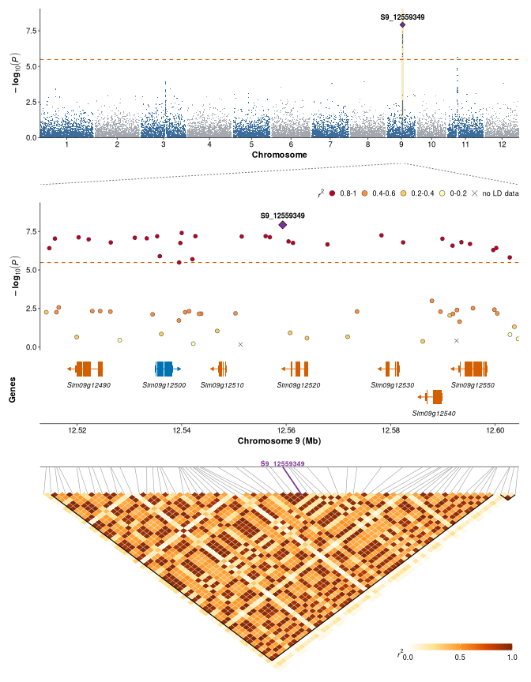

```r
res$plot
```

The tables are written next to the PDF. The SNP table gives, for every GWAS SNP in the region, its P value, its r<sup>2</sup> with the lead SNP and where it lies relative to the nearest gene:

```r
head(res$snp_table[, c("SNP", "POS", "P", "R2_WITH_LEAD", "GENE", "LOCATION", "FEATURE")])
```

```
#>           SNP      POS         P R2_WITH_LEAD        GENE   LOCATION FEATURE
#> 1 S9_12514103 12514103 5.485e-03       0.2482 Sim09g12480 intergenic    <NA>
#> 2 S9_12514676 12514676 3.856e-07       0.9529 Sim09g12480 intergenic    <NA>
#> 3 S9_12515756 12515756 9.137e-08       0.9904 Sim09g12490 intergenic    <NA>
#> 4 S9_12516047 12516047 5.450e-03       0.5155 Sim09g12490 intergenic    <NA>
#> 5 S9_12516486 12516486 2.698e-03       0.5376 Sim09g12490 intergenic    <NA>
#> 6 S9_12519922 12519922 2.227e-01       0.2697 Sim09g12490       exon     CDS
```

Panels and tables are chosen independently, so the LD table can be written without the heatmap, or tables can be written without any figure:

```r
r2 <- quard_plot(my$gwas, my$gff, my$vcf, chr = ex$chr, pos = ex$pos,
                 panels = c("regional", "genes"), tables = c("snps", "ld"),
                 output = file.path(out, "locus_no_heatmap.pdf"), verbose = FALSE)
names(r2$files)
```

```
#> [1] "pdf"       "snps"      "ld_matrix" "readme"
```

With `table_format = "xlsx"` (needs the writexl package) all tables are put in one Excel file with a README sheet.

## 4. LD and LD blocks

```r
g <- genotype_qc(read_vcf(my$vcf, chr = 9, verbose = FALSE), verbose = FALSE)
ld <- calc_ld(g)                       # r2 as in PLINK 1.9 --r2
blocks <- find_ld_blocks(g, verbose = FALSE)   # Gabriel method, as in PLINK --blocks
head(blocks[, c("chr", "start", "end", "kb", "nsnps")])
```

```
#>   chr    start      end     kb nsnps
#> 1   9 12402078 12449460 47.383    43
#> 2   9 12451612 12476379 24.768    16
#> 3   9 12478070 12514103 36.034    33
#> 4   9 12514676 12602793 88.118    61
#> 5   9 12602843 12624883 22.041    14
#> 6   9 12626277 12655651 29.375    21
```

## 5. Where SNPs lie relative to genes

```r
a <- annotate_variants(g, my$gff)
table(a$location)
```

```
#>
#> downstream       exon intergenic     intron   upstream
#>         17         36        102         22         56
```

## 6. Other tools

```r
genes <- get_genes(my$gff, chr = 9, pos = ex$pos, flank = 20000, verbose = FALSE)
genes[, c("gene_id", "start", "end", "strand", "distance_bp")]
```

```
#>       gene_id    start      end strand distance_bp
#> 1 Sim09g12510 12546925 12548628      -       10721
#> 2 Sim09g12520 12560551 12564272      -        1202
#> 3 Sim09g12530 12578977 12581758      -       19628
```

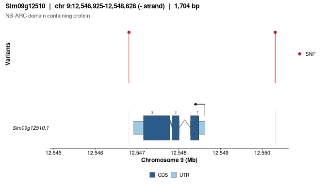

```r
plot_gene_structure(my$gff, genes$gene_id[1], flank = 2000, variants = my$vcf)
```

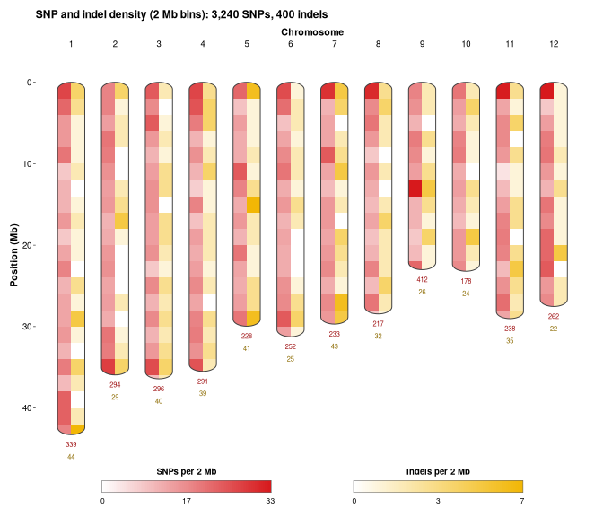

```r
plot_karyotype(my$hapmap, bin_size = 2e6, verbose = FALSE)
```

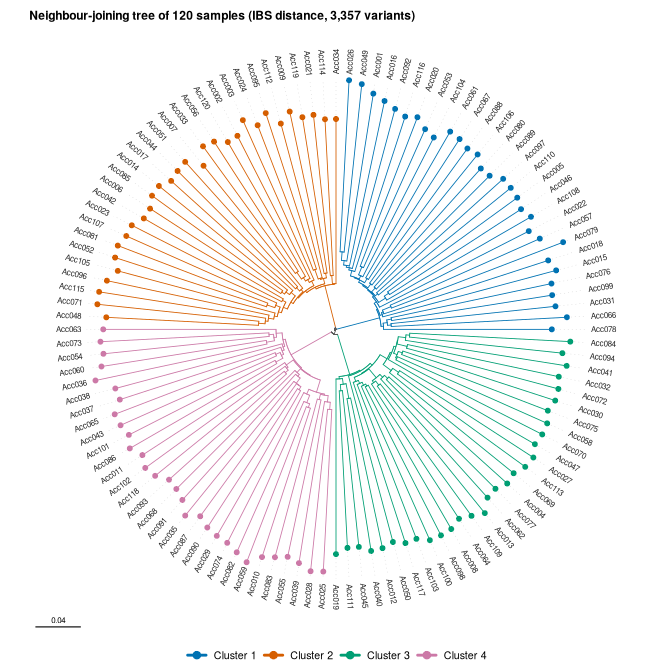

```r
tr <- hapmap_tree(my$hapmap, file.path(out, "tree.pdf"), k = 4, verbose = FALSE)
tr$plot
```

## 7. From a terminal

```
Rscript -e "quardplot::quard_cli()" --help
Rscript -e "quardplot::quard_cli()" --species rice --gwas gwas.csv --gff genes.gff3 \
        --vcf genotypes.vcf.gz --target top --out results/locus.pdf
```